# Análisis de Datos en el Comercio

Jeremías Mogollón

Hilary Andrade

Ronald Camacho

Angel Mogollón

Noviembre 2026

Abstract

El presente trabajo analiza el comportamiento de las transacciones comerciales y el rendimiento de ventas en el sector retail mediante el procesamiento estadístico en R y RStudio. A partir de datos transaccionales de 2022–2025, se examinan variables como precios, cantidades, montos, categorías, métodos de pago y canales de venta (Online e In-store). Metodológicamente, se implementa un flujo reproducible en RMarkdown para la limpieza, análisis descriptivo y visualización gráfica. Los hallazgos permiten identificar patrones de consumo y la efectividad de las políticas de descuentos, optimizando la toma de decisiones comerciales. Palabras clave, Análisis de datos, RMarkdown, Comercio minorista, Estadísticas descriptivas, Reproducibilidad….

El análisis de datos en el comercio minorista (retail) es fundamental para comprender la dinámica del mercado y el comportamiento de los consumidores. Ante el volumen masivo de registros transaccionales presenciales y digitales, las empresas requieren metodologías estadísticas precisas para optimizar sus operaciones. Este informe se estructura para dar respuesta a interrogantes clave sobre las ventas minoristas. Comienza con el Planteamiento del Problema (justificación, objetivos, cobertura y definición de variables). Posteriormente, aborda la limpieza de datos, el análisis estadístico descriptivo para resolver las preguntas de investigación y la generación de visualizaciones integradas. Todo el desarrollo se ejecuta bajo un enfoque de reproducibilidad mediante un documento dinámico en RMarkdown.

El sector del comercio al por menor (retail) opera en un entorno altamente dinámico y competitivo, donde la gestión eficiente de las transacciones comerciales, la comprensión de los patrones de consumo y la optimización de los canales de venta (físico y digital) resultan fundamentales para la sostenibilidad financiera de los establecimientos. La irrupción de nuevas modalidades de pago, como las billeteras digitales y tarjetas, combinada con políticas de descuentos dinámicos y la diversificación de categorías de productos, genera un volumen masivo de datos transaccionales que requieren un tratamiento analítico riguroso.

¿De qué manera influyen las categorías de productos y los canales de distribución (Online vs. In-store) en el volumen total de ventas de la tienda?

¿Existe una relación significativa entre la aplicación de descuentos y los métodos de pago preferidos por los consumidores en el monto total gastado por transacción?

¿Cómo se distribuyen los precios unitarios y las cantidades adquiridas a lo largo del periodo de referencia, permitiendo identificar patrones estacionales o anomalías en el comportamiento de compra?

¿En qué categorías se aplican más descuentos?

La presente investigación se justifica en la necesidad de dotar a la gestión comercial minorista de herramientas estadísticas objetivas y reproducibles. A nivel práctico, el análisis detallado de las transacciones correspondientes al periodo 2022-2025 permitirá optimizar las estrategias de precios, la segmentación de clientes y la asignación de recursos operativos entre los canales digitales y físicos. Desde una perspectiva metodológica, el estudio establece un flujo de trabajo reproducible basado en programación estadística, garantizando la trazabilidad, la precisión y la transparencia en el tratamiento de los datos. Esto aporta valor estratégico a la organización y consolida un marco de aplicación directa para la analítica empresarial en el ámbito académico.

El estudio abarca el análisis económico y cuantitativo del rendimiento comercial minorista (retail), centrándose en el estudio de las transacciones de venta, la tipología de los artículos comercializados, las preferencias de pago de los clientes y la segmentación geográfica u operativa de las compras.

La cobertura operativa y espacial comprende los registros de ventas recopilados tanto a través de la plataforma de comercio electrónico (Online) como en las sucursales físicas (In-store), abarcando la totalidad de las observaciones válidas contenidas en el repositorio de datos de la empresa.

El análisis empírico se fundamenta en el procesamiento del histórico transaccional correspondiente al periodo comprendido entre los años 2022-2025, permitiendo capturar la estacionalidad anual y las variaciones temporales en el comportamiento de compra de los clientes.

Las variables objeto de estudio se han estructurado rigurosamente en función de su naturaleza matemática y estadística en R, clasificándose en variables cuantitativas (continuas y discretas para el análisis de montos y volúmenes) y cualitativas (factores para la segmentación por categorías, canales de pago y ubicación geográfica)

Aquí se presentan de manera sencilla las bases del tema y del comportamiento del consumidor que respaldan el análisis de cómo las promociones influyen en las ventas de las tiendas.Su importancia está en explicar cómo piensan los compradores y cómo reaccionan las ventas cuando se aplican descuentos, modifican el ticket de compra y condicionan el desempeño comercial a través de los distintos canales y modalidades de pago.

Las promociones de ventas y las políticas de descuento de precios constituyen estímulos comerciales directos destinados a acelerar la decisión de compra, atraer nuevos compradores y elevar la rotación de inventarios. En términos transaccionales, el descuento representa una disminución porcentual o absoluta respecto al precio regular de lista (Price Per Unit), modificando la restricción presupuestaria del cliente, esta herramienta altera la restricción presupuestaria del cliente mediante dos fuerzas:

**-Efecto sustitución:** Cuando un producto baja de precio, se vuelve más atractivo que otras opciones similares o de la competencia que mantienen su precio normal. **-Efecto ingreso:** Aumenta la capacidad de compra de las personas, permitiéndoles llevar más productos gastando lo mismo.

En la tienda , el impacto de una promoción va más allá de un solo artículo influye directamente en la cantidad y variedad de productos que el cliente decide llevar Los compradores suelen dividir su dinero en ‘presupuestos mentales’ según el tipo de compra que van a hacer . Al notar que ahorran dinero con un descuento, los compradores suelen reaccionar de dos formas clave:

**-Efecto acaparamiento o compra acelerada:** El cliente adelanta compras futuras o incrementa el volumen físico adquirido para maximizar el beneficio del precio rebajado antes de que expire la oferta.

**-Comportamiento compensatorio de gasto:** El dinero que el comprador se ahorra en un producto en promoción suele destinarse a sumar más artículos al carrito o a elegir versiones más costosas, impactando directamente en el ticket promedio de compra.

El impacto de estas promociones depende del tipo de producto, los artículos de consumo rápido o perecederos suelen comprarse por impulso con cualquier oferta puntual, mientras que los productos duraderos o que requieren mayor planificación necesitan descuentos mucho más altos para convencer al cliente.

El resultado de las promociones en los comercios actuales depende tanto de la experiencia en el punto de venta como de la rapidez al pagar.

**-Diferencia entre canal físico (In-store) y digital (Online):** Al comprar en persona, ver los productos y tenerlos disponibles al instante motiva a los clientes a llevarse cosas extra que no planeaban, además de aprovechar el descuento. Por otro lado, comprar por internet hace muy fácil comparar precios al instante y sin esfuerzo. Esto vuelve a los clientes más exigentes y enfocados solo en buscar ofertas, lo que puede reducir la compra de productos adicionales si la página no les muestra buenas sugerencias.

**-El impacto de la facilidad de pago en la decisión de compra:** El medio elegido para pagar influye en nuestra percepción del gasto. Los pagos electrónicos y las tarjetas de crédito retrasan la sensación de estar perdiendo dinero en efectivo, lo que reduce la resistencia del cliente al momento de comprar. Al no sentir el golpe inmediato en el bolsillo y aprovechar un buen descuento, es mucho más probable que el cliente agregue más productos a su compra que si tuviera que pagar en efectivo al momento

La presente investigación es de tipo descriptivo y cuantitativo, con un diseño no experimental y de corte transversal. Se busca caracterizar y describir el comportamiento de las ventas minoristas, particularmente el efecto de la aplicación de descuentos sobre el monto total gastado y la cantidad de productos adquiridos, sin manipular variables. Se adopta un enfoque cuantitativo, ya que se trabaja con una base de datos numérica y categórica que permite el uso de técnicas de estadística descriptiva para resumir, organizar y presentar la información de manera objetiva.

Se utiliza una base de datos secundaria correspondiente a las transacciones de un local minorista, que contiene 12.575 registros de ventas realizadas tanto en el canal Online como en el canal In-store, durante el periodo 2022-2025. La base incluye variables relacionadas con la identificación de la transacción, categoría del producto, precio unitario, cantidad, monto total, método de pago, ubicación y aplicación de descuento.

-Variables cuantitativas:

Continuas: Price Per Unit, Total Spent Discretas: Quantity

-Variables cualitativas (categóricas): Category, Item, Payment Method, Location, Discount Applied

La variable principal de análisis es Discount Applied (aplicación de descuento), la cual se estudia en relación con el monto total gastado (Total Spent) y la cantidad comprada (Quantity).

-Tablas de frecuencias y porcentajes -Medidas de tendencia central (media y mediana) -Medidas de dispersión (desviación estándar) -Tablas de contingencia -Representaciones gráficas: gráficos de barras y diagramas de caja (boxplots)

El procesamiento, limpieza, análisis y generación de visualizaciones se realizó utilizando el lenguaje de programación R a través del entorno RStudio, mediante un documento dinámico en R Markdown, lo que garantiza la reproducibilidad del estudio. Se emplearon principalmente los paquetes tidyverse, knitr y kableExtra.

1.Importación y revisión de la base de datos.

2.Limpieza y tratamiento de valores faltantes (imputación por mediana según categoría y recodificación de valores nulos en variables categóricas).

3.Análisis descriptivo univariado de la variable Discount Applied.

4.Análisis comparativo de Total Spent y Quantity según la aplicación de descuento.

5.Análisis cruzado de los descuentos según categoría de producto, canal de venta (Online / In-store) y método de pago.

6.Generación de tablas y gráficos interpretativos.

7.Elaboración de conclusiones a partir de los hallazgos descriptivos.

{Este capítulo presenta los resultados obtenidos al aplicar las metodologías descritas en el capítulo anterior, así como del análisis estadístico descriptivo de las variables estudiadas y las ventajas y desventajas al aplicar dichos tests.

Esta sección presenta el análisis estadístico descriptivo orientado a evaluar el impacto de la aplicación de descuentos (discount) sobre el comportamiento de compra de los clientes, analizando variables clave como el monto total gastado (total_spent) y la cantidad de unidades adquiridas (quantity).

Para contextualizar los hallazgos, primeramente se examina la proporción general de transacciones que cuentan con algún tipo de rebaja. Posteriormente, se contrasta el rendimiento económico y de volumen entre las compras que incluyeron descuento frente a aquellas que no lo hicieron, profundizando en cómo este factor interactúa según las categorías de productos y los canales de distribución (Online e In-store)}

De las 12.575 transacciones analizadas, se observó una distribución muy equilibrada en la variable de descuento. Aproximadamente un tercio de las transacciones tuvieron descuento aplicado (TRUE: 33.6%), otro tercio no lo tuvo (FALSE: 33.1%) y el tercio restante corresponde a valores desconocidos (33.4%). Esta distribución similar indica que la política de descuentos no se aplica de manera dominante en ninguna de las dos direcciones.

Distribucion de la variable Discount Applied

| Descuento | Frecuencia | Porcentaje (%) |
| --- | --- | --- |
| FALSE | 4157 | 33.1 |
| TRUE | 4219 | 33.6 |
| NA | 4199 | 33.4 |

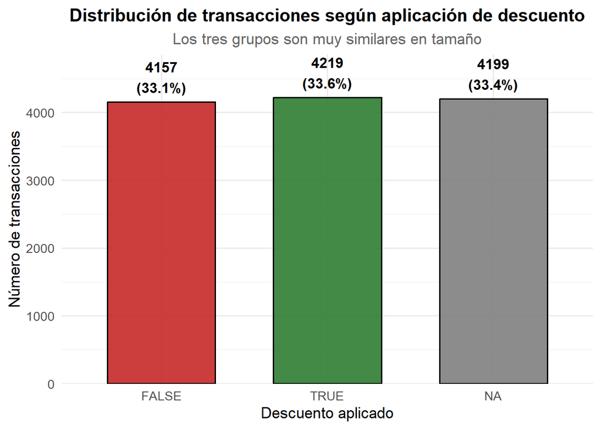

Al comparar el monto total gastado (Total Spent) y la cantidad de productos comprados (Quantity) según la aplicación de descuento, se evidencia que las diferencias son mínimas. La media de Total Spent fue de 130.49 en las transacciones con descuento y de 129.95 en las que no lo tuvieron. De igual forma, la cantidad promedio comprada se mantuvo muy similar (5.53 vs 5.58). Los diagramas de caja confirman esta similitud, mostrando distribuciones casi idénticas entre ambos grupos, con presencia de valores atípicos en los tres casos.

Medidas de resumen de Total Spent y Quantity según Descuento

| Descuento | N | Media Total | Mediana Total | Desv. Total | Media Cantidad | Mediana Cantidad | Desv. Cantidad |
| --- | --- | --- | --- | --- | --- | --- | --- |
| FALSE | 4157 | 129.95 | 109.5 | 93.35 | 5.58 | 6 | 2.85 |
| TRUE | 4219 | 130.49 | 109.5 | 95.54 | 5.53 | 6 | 2.85 |
| NA | 4199 | 128.51 | 105.0 | 95.35 | 5.49 | 6 | 2.88 |

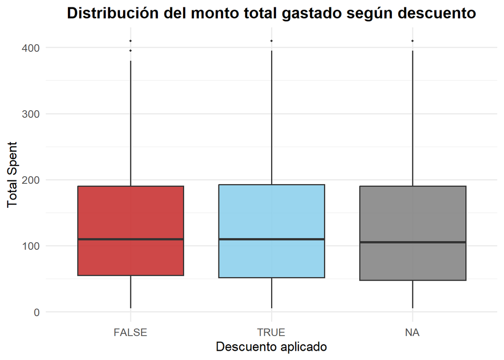

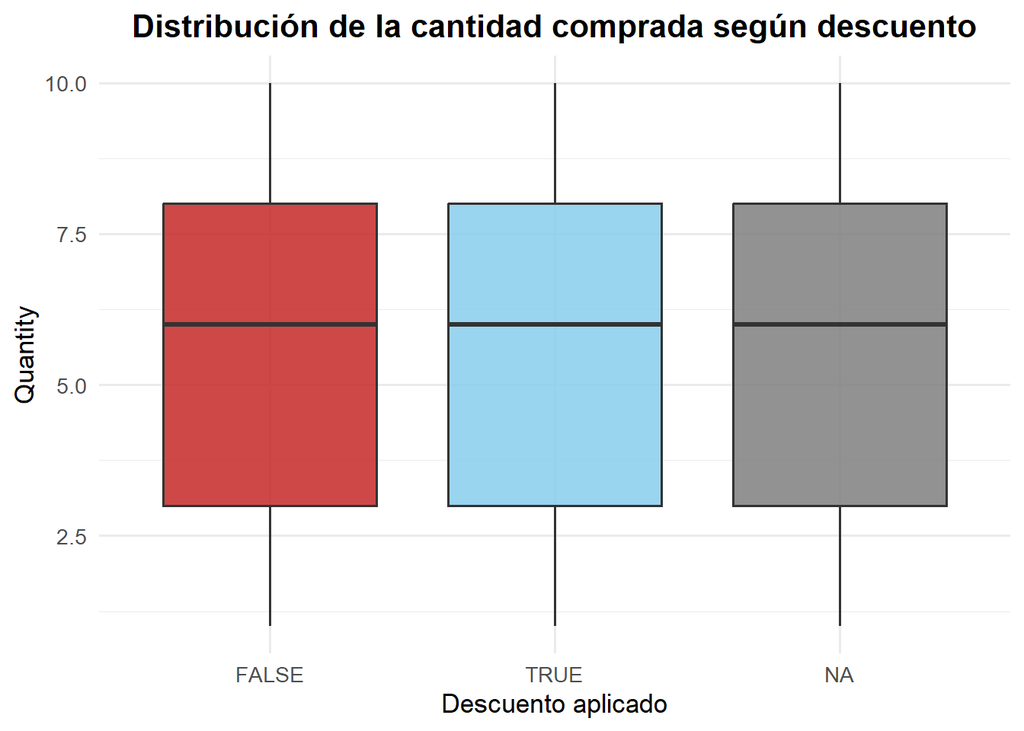

Al analizar el grafico de descuentos por categoría, se identificó que la categoría Furniture es donde se aplican con mayor frecuencia los descuentos, mientras que la categoría Food presenta la menor proporción de transacciones con descuento. El resto de las categorías muestran un comportamiento intermedio y relativamente homogéneo.

Distribucion de descuentos segun categoria (solo TRUE y FALSE)

| Categoria | Descuento | Frecuencia | Porcentaje (%) |
| --- | --- | --- | --- |
| Beverages | FALSE | 495 | 48.7 |
| Beverages | TRUE | 521 | 51.3 |
| Butchers | FALSE | 514 | 48.6 |
| Butchers | TRUE | 543 | 51.4 |
| Computers and electric accessories | FALSE | 546 | 50.5 |
| Computers and electric accessories | TRUE | 535 | 49.5 |
| Electric household essentials | FALSE | 528 | 50.3 |
| Electric household essentials | TRUE | 522 | 49.7 |
| Food | FALSE | 547 | 51.8 |
| Food | TRUE | 508 | 48.2 |
| Furniture | FALSE | 486 | 47.6 |
| Furniture | TRUE | 535 | 52.4 |
| Milk Products | FALSE | 549 | 50.4 |
| Milk Products | TRUE | 540 | 49.6 |
| Patisserie | FALSE | 492 | 48.9 |
| Patisserie | TRUE | 515 | 51.1 |

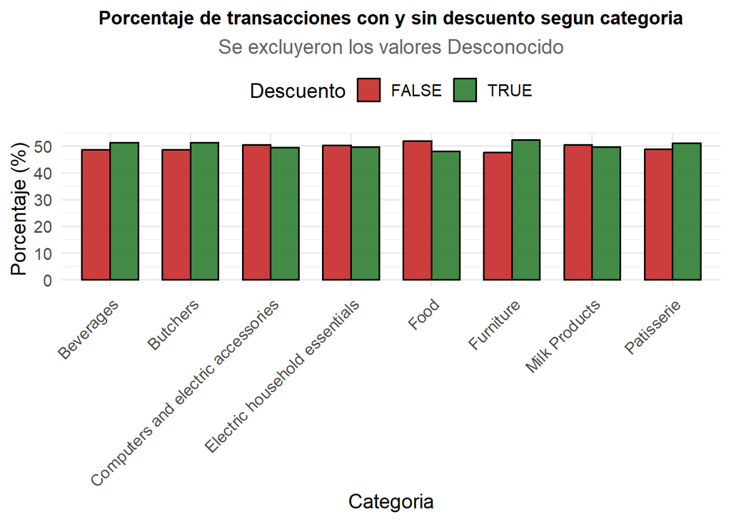

Respecto al canal de venta, la diferencia entre Online e In-store es pequeña. Ambos canales presentan proporciones de descuento muy cercanas, lo que sugiere que la política de descuentos se aplica de manera similar independientemente del canal utilizado por el cliente.

Distribucion de descuentos segun canal de venta (Online vs In-store)

| Location | Descuento | Frecuencia | Porcentaje (%) |
| --- | --- | --- | --- |
| In-store | FALSE | 2055 | 49.8 |
| In-store | TRUE | 2070 | 50.2 |
| Online | FALSE | 2102 | 49.4 |
| Online | TRUE | 2149 | 50.6 |

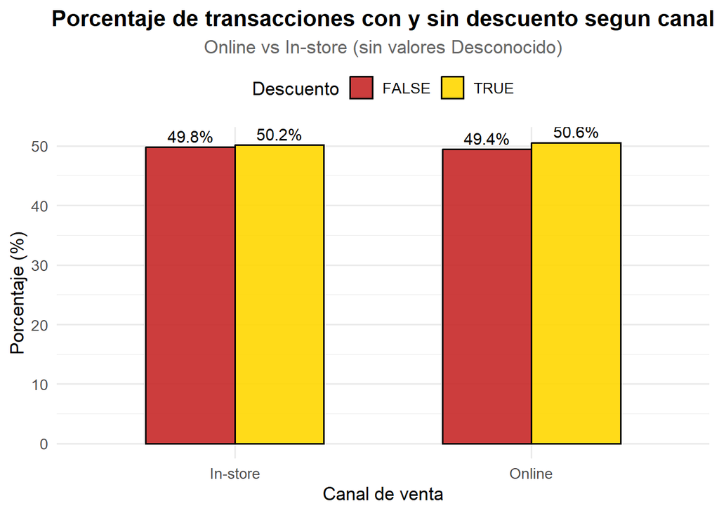

En cuanto a los métodos de pago, se observó que las transacciones realizadas en Cash son las que presentan mayor proporción de descuentos aplicados, mientras que Digital Wallet muestra la menor proporción. Este comportamiento podría estar relacionado con estrategias promocionales específicas según el medio de pago.

Distribucion de descuentos segun metodo de pago

| Metodo de Pago | Descuento | Frecuencia | Porcentaje (%) |
| --- | --- | --- | --- |
| Cash | FALSE | 1378 | 48.6 |
| Cash | TRUE | 1459 | 51.4 |
| Credit Card | FALSE | 1359 | 49.3 |
| Credit Card | TRUE | 1397 | 50.7 |
| Digital Wallet | FALSE | 1420 | 51.0 |
| Digital Wallet | TRUE | 1363 | 49.0 |

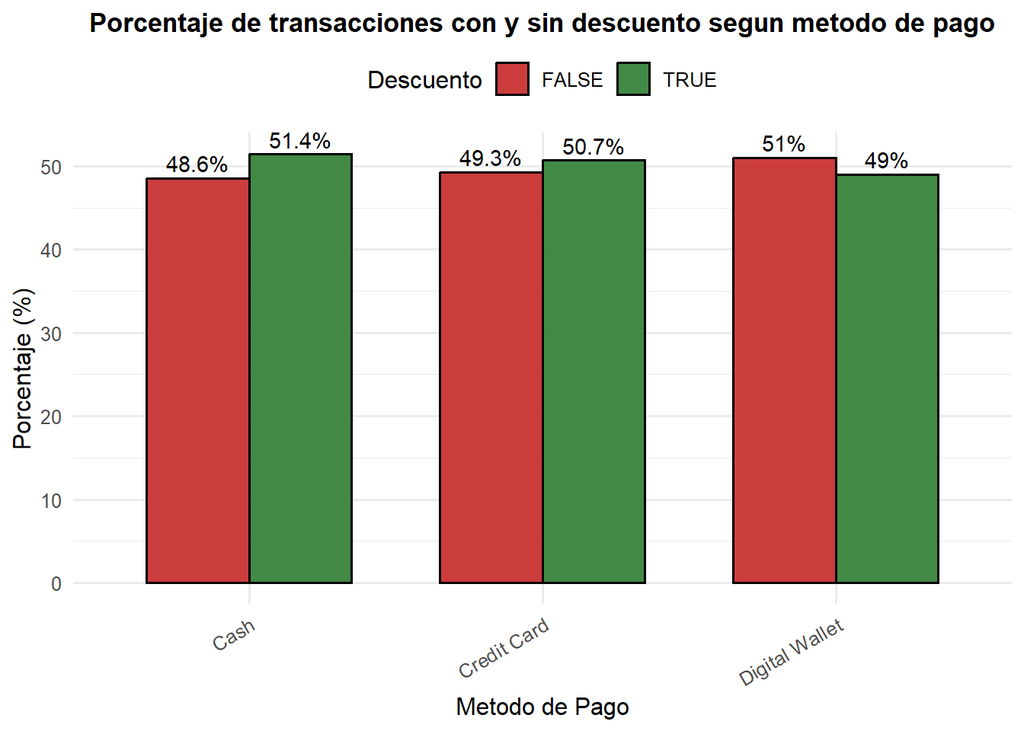

Ticket promedio (Total Spent) segun metodo de pago y descuento

| Metodo de Pago | Descuento | N | Media | Mediana |
| --- | --- | --- | --- | --- |
| Cash | FALSE | 1378 | 131.24 | 111.0 |
| Cash | TRUE | 1459 | 134.06 | 110.0 |
| Credit Card | FALSE | 1359 | 132.84 | 112.0 |
| Credit Card | TRUE | 1397 | 127.56 | 107.5 |
| Digital Wallet | FALSE | 1420 | 125.90 | 102.0 |
| Digital Wallet | TRUE | 1363 | 129.68 | 108.0 |

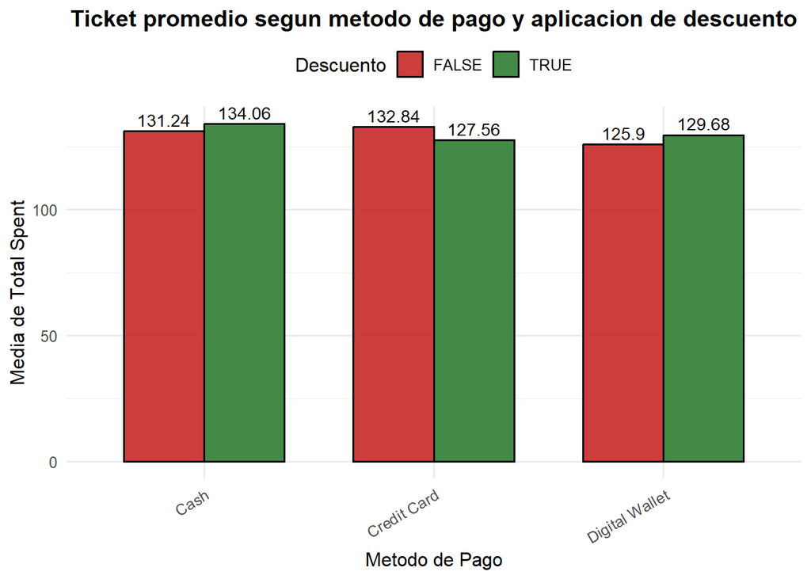

El procesamiento y análisis estadístico de un histórico de 12.575 transacciones del sector retail (2022-2025), implementado a través de un flujo de trabajo reproducible en R, RStudio y RMarkdown, demostró ser una herramienta robusta y transparente para el tratamiento de datos y la gestión comercial. La limpieza y el tratamiento de valores faltantes mediante imputación por mediana permitieron mantener la integridad de la base de datos sin sesgar las distribuciones univariadas y multivariadas.

Mantener y ampliar el enfoque de programación reproducible (RMarkdown) en futuros análisis comerciales de la organización para garantizar la trazabilidad, rapidez y precisión en la actualización periódica de los reportes gerenciales.

La distribución global de la variable de descuentos muestra una participación sumamente equilibrada y fragmentada en tercios casi idénticos entre transacciones con descuento (TRUE: 33.6%), sin descuento (FALSE: 33.1%) y valores no especificados (NA: 33.4%). Asimismo, las medidas de tendencia central y dispersión del monto total gastado (Total Spent, con medias cercanas a 130) y de las cantidades adquiridas (Quantity, con medias en torno a 5.5 unidades) evidencian que la presencia o ausencia de un descuento por sí sola no genera un cambio drástico en el volumen promedio por transacción a nivel general.

Evaluar y rediseñar las políticas de incentivos comerciales actuales, dado que una distribución tan equitativa entre compras con y sin descuento sugiere que las promociones vigentes no están logrando el efecto diferenciador esperado sobre el ticket promedio global.

Al analizar el comportamiento de los descuentos por categorías de productos, se identificó que rubros como Furniture (52.4%), Butchers (51.4%), Beverages (51.3%) y Patisserie (51.1%) concentran las mayores proporciones de transacciones con rebajas aplicadas, mientras que la categoría Food registra la menor incidencia con un 48.2%. Esto refleja un esfuerzo promocional diferenciado según la naturaleza de los artículos comercializados.

Focalizar las estrategias de rebajas en categorías de alta rotación o aquellas con menor sensibilidad al precio (como Food), implementando promociones cruzadas o descuentos por volumen para estimular un mayor incremento en el ticket de compra en dichos departamentos.

Desarrollar estrategias promocionales específicas para el entorno digital que aprovechen la facilidad de comparación de precios en línea, tales como ofertas flash o cupones exclusivos para el canal Online, con el fin de potenciar la captación de clientes digitales más exigentes.

El análisis cruzado entre los métodos de pago y la aplicación de descuentos evidencia comportamientos heterogéneos en el ticket promedio (Total Spent). Mientras que los pagos en efectivo (Cash, que pasa de 131.24 a 134.06) y mediante billeteras digitales (Digital Wallet, que aumenta de 125.90 a 129.68) muestran un incremento en el monto promedio gastado cuando se aplica un descuento, las transacciones con tarjeta de crédito (Credit Card) experimentan un comportamiento inverso, disminuyendo su media de 132.84 a 127.56.

Optimizar las alianzas con pasarelas de pago digitales y canales de efectivo mediante incentivos combinados (como cashback o descuentos adicionales), y revisar las condiciones asociadas al uso de tarjetas de crédito para entender por qué el descuento reduce marginalmente el ticket en este método de pago.